# Circular Motion Notes

## Joseph E. McEwen, 2020 (c)

### version 0.01

**These notes/notebook are a first draft, please report any typos or errors.**

**Note: this notebook cannot be distributed or copied without the author's permission. Make sure you fully understand this.**

**Students should ignore any code and pay attention to plots, animations, and text.**

**These notes should accompany your textbook. Don't get the impression that these notes replace your normal textbook reading or lectures.**

## Are animations useful?

There a lot of animations in this notebook. Are they useful for learning purposes? Probably. But, they are not the best way. I am not that old, but what I can tell you is that when I was in your position, animations were really hard to come by. Even now, they are still hard to make. Many people learned physics without animations, you can too. (Ditto for Youtube, Khan accademy, Chegg and ...) The best strategy is to employ the method we use in class, where we make a series of plots, snapshots of the scenario at various points in time. This method really makes you think about what is going on. Animations are too easy - you often feel like you fully understand, when in fact you really need to spend some time thinking. I encourage you to take the "drawing of snapshot" approach, you can even do that while you are reading these notes.

```python
import numpy as np
import sympy as sym
from numpy import pi
%matplotlib inline
import matplotlib.pyplot as plt
from matplotlib import animation
from IPython.display import HTML

from numpy import cos, sin, pi

%load_ext autoreload
%autoreload 2

from circ_motion_plots import circ_frame, circ_diagram
from circ_motion_animations import animate_circ, animate_frame, animate_variables
```

```
The autoreload extension is already loaded. To reload it, use:
  %reload_ext autoreload
```

## Intro

The animation below exemplifies circular motion. The green dot represents our object of interest, perhaps a planet orbiting the sun, or a car traversing a curved road. A few points to mention:

- In circular motion the object of interest is always at a fixed distance from the origin. We will call this distance $r$, the radius of the circle.
- The velocity of the object is always tangential to circular path. In the animation below the velocity vector is represented by the blue arrow attached to the green dot. Not only should we intuitively understand that the velocity is tangent to the curve, but understand that this is mathematically consistant too. Afterall, the velocity is the derivative with respect to time of the position vector. Recall the derivative as the slope of the line tangent to the trajectory of the object.

```python
anim=animate_circ()
HTML(anim.to_html5_video())
```

[video not shown]

### Types of circular motion

There are two types of circular motion we will study:

- **uniform circular motion** occurs when the speed of the object remains constant
- **non-uniform circular motion** occurs when the speed of the object varies

**Problem 1**

In the animation above, the object is undergoing uniform circular motion, i.e., the speed of the object is constant. You should not see the object slowing down or speeding up. In this case, is the velocity constant too? Is the magnitude of the acceleration zero or non-zero? If the magnitude of the acceleration is constant, is the acceleration constant too? Explain your answer.

### Angular variables and position

- Theta, $\theta=\theta(t)$, is the angle measured from the horizontal to the line defined by the radius. It is important to note, that $\theta$, is dynamic, i.e., it varies with time.
- Omega, $\omega = d\theta/dt$, is the rate at which $\theta$ varies with time. $\omega$ is referred to as the angular velocity.
- Alpha, $\alpha = d \omega/dt$, is that rate at which $\omega$ varies with time. $\alpha$ is referred to as the angular acceleration.
- The position of the object is given by $\vec{r} = x \hat{i} + y\hat{j}$ where $x=r \cos \theta$ and $y=r\sin \theta$.

**Problem 2**

Suppose $r=10~m$, $\theta=A~ t^2$, where $A=\pi/3$. What are the units on $A$? What is the position vector $\vec{r}$, $\omega$, and $\alpha$ at $t=\sqrt{2}$? Plot the position vector at $t=\sqrt{2}$. Make plots of $\theta$, $\omega$, and $\alpha$ as a function of time (3 separate plots).

**Problem 3**

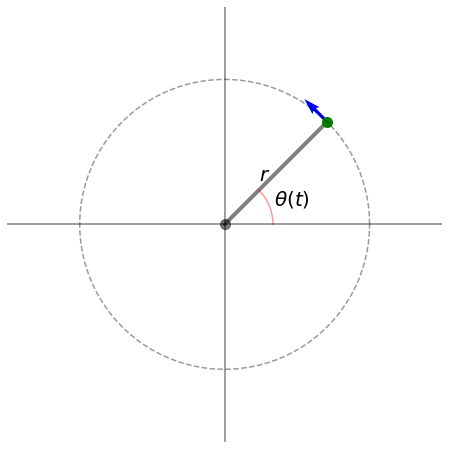

```python
circ_diagram()
```

## The mathematics of circular motion

We are going to need two concepts from differential calculus:

- The product rule \begin{align} \frac{d}{dx} fg = g \frac{df}{dx} + f \frac{dg}{dx} ~, \end{align} where $f$ and $g$ are functions of $x$.
- The chain rule \begin{align} \frac{d}{dx} f(g(x))= \frac{df}{dg}\frac{dg}{dx} ~. \end{align}

**Problem 4**

In the case of circular motion, $\theta$ is a function of time. Explain why \begin{align} \frac{d}{dt} \cos \theta = - \sin \theta \frac{d\theta}{dt} ~. \end{align} What is the time derivative of $\sin \theta$?

### An additional coordinate system

The form of the radial unit vector in terms of $\hat{i}$ and $\hat{j}$ is \begin{align} \hat{r}= \cos \theta \hat{i} + \sin \theta \hat{j} ~. \end{align}

**Problem 5**

Show that the position vector $\vec{r} = x \hat{i} + y \hat{j} = r \hat{r}$. What is $r$ in terms of $x$ and $y$?

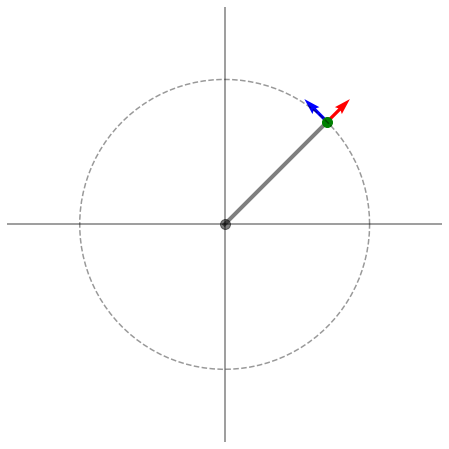

```python
circ_frame(pi/4)
```

The form of the unit vector in the $\theta$ direction is \begin{align} \hat{\theta}= -\sin \theta \hat{i} + \cos \theta \hat{j} ~. \end{align}

We don't just yet have the mathematical ability to prove the above formula, but we can justify it. Let us take a look at the situation when $\theta = \pi/2$, see diagram below. In this case the unit vector $\hat{\theta}$ is in the negative $\hat{i}$ direction, based off the diagram. Substituting $\theta=\pi/2$ into the the above formula gives \begin{align} \hat{\theta}(\theta=\pi/2)= -\sin \pi/2 \hat{i} + \cos \pi/2 \hat{j} = -\hat{i} ~, \end{align} and the result matches what we expected from the diagram.

**Problem 6**

Do the same analysis as above for $\theta=0, ~ \pi, ~3\pi/2$. Be sure to include plots.

*We should be sure to note that we ought to check our expressions. Strategies to do this include: unit analysis, limiting cases, cases in which we know the result (like the above problem), and consistant with physical limits (like velocities not being faster than the speed of light).*

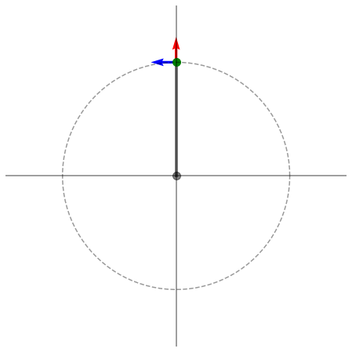

```python
circ_frame(pi/2)
```

One important note to make is that the unit vectors $\hat{r}$ and $\hat{\theta}$ are dynamic. That is, their values change with time (in contrast to the $\hat{i}$ and $\hat{j}$ that are constant in time). This will have important consequences when we apply derivatives. Below is an animation that includes the $\hat{r}$ and $\hat{\theta}$ attached to the object.

```python
anim=animate_frame()
HTML(anim.to_html5_video())
```

[video not shown]

### Velocity

Starting with the position vector $\vec{r}=r \hat{r}$ the velocity is computed as \begin{align} \begin{split} \vec{v}& = \frac{d}{dt} \vec{r} \\ & = \frac{dr}{dt} \hat{r} + r \frac{d \hat{r} }{dt} \\ & = 0 + r \frac{d \theta}{dt} \hat{\theta} \\ & = r \omega \hat{\theta} ~. \end{split} \end{align}

**Problem 7**

In the expression above, where does the zero in the third line come from? In the third line, a $\hat{\theta}$ appears - where did this come from? Hint, take the time derivative of $\hat{r}$. In the last line, there is an $\omega$ - where did this come from? Should we have expected the velocity to be in the $\hat{\theta}$ direction?

Our result shows that the magnitude of the velocity is $r \omega$. We could have determined this earlier. Recall the formula for arc-length, $s=r \theta$. A small segment of the circular trajectory would be $ds=rd\theta$. The magnitude of the velocity would then be calculated as \begin{align} \begin{split} v & = \frac{ds}{dt} \\ & =r \frac{d \theta}{dt} = r \omega~. \end{split} \end{align}

**Problem 8**

Draw a picture illustrating this phrase:

*Recall the formula for arc-length, $s=r \theta$. A small segment of the circular trajector would be $ds=rd\theta$.* This will be your picture, so draw and label as you like.

### Acceleration

The acceleration is calculated as

\begin{align} \begin{split} \vec{a}& = \frac{d}{dt} \vec{v} \\ & = \frac{dr}{dt} \omega \hat{\theta} + r \frac{d \omega }{dt}\hat{\theta} + r \omega \frac{d \hat{\theta}}{dt} \\ & = 0 + r \alpha \hat{\theta} - r \omega \frac{d \theta}{dt} \hat{r} \\ & = \underbrace{r \alpha \hat{\theta}}_{a_t}~ \underbrace{- ~r \omega^2 \hat{r} }_{a_r} ~, \end{split} \end{align}

where the tangential acceleration is \begin{align} \vec{a}_t= r \alpha \hat{\theta}~, \end{align} and the radial acceleration is \begin{align} \vec{a}_r= - ~r \omega^2 \hat{r}~. \end{align}

**Problem 9**

In the derivation above, where did the $\alpha$ come from in the third line? How did $\omega^2$ appear in the fourth line?

When $\alpha$ is zero, the accleration is only in the radial direction, $\vec{a} = - r \omega^2 \hat{r}$. This is the case of uniform circular motion, i.e., constant $\omega$.

**Problem 10**

If $\omega$ is a constant, what is $\alpha= d \omega/dt$? (Easy, but we should just make sure about this.)

## Why is the radial acceleration in the negative radial direction?

An object's motion changes because the object is subject to a force. This is Newton's second law, $\vec{F}=m \vec{a}$. Newton's second law tells us that the acceleration and force are in the same direction. Newton's second law also restates Newton's first law, which is often recalled as "an object in motion will stay in motion unless acted on by an outside force". So, if we look at any of our animations for circular motion, we see that the velocity vector is constantly changing direction (the motion is constantly changing). What is the direction of the force needed so that the velocity vector changes direction, so that it is always pointing tangential to a circular curve? The answer is that the force is directed radially inwards.

### Examples (and problems)

In each of the cases below a funtion for $\theta(t)$ is displayed. For each case write down the initial $\theta$ value ($\theta(t=0)=?$), the expression for $\omega(t)$, the expression for $\alpha(t)$. Determine if the motion is uniform or non-uniform circular motion. Watch the animation and describe the motion relating what you observe to the mathematical expressions.

**Problem 11**

```python
theta,t=sym.symbols("theta,t")
theta=pi/3 + t - .5*t**2
print("Expression for theta:")
display(theta)
expression=[theta,t]
time=np.linspace(0,5,100)
anim=animate_variables(expression,time,interval=100)
HTML(anim.to_html5_video())
```

```
Expression for theta:
```

$\displaystyle - 0.5 t^{2} + t + 1.0471975511966$

[video not shown]

**Problem 12**

```python
theta,t=sym.symbols("theta,t")
theta=pi/3 + t
print("Expression for theta:")
display(theta)
expression=[theta,t]
time=np.linspace(0,5,100)
anim=animate_variables(expression,time,interval=100)
HTML(anim.to_html5_video())
```

```
Expression for theta:
```

$\displaystyle t + 1.0471975511966$

[video not shown]

**Problem 13**

```python
theta,t=sym.symbols("theta,t")
theta=pi/4 + t**3
print("Expression for theta:")
display(theta)
expression=[theta,t]
time=np.linspace(0,5,100)
anim=animate_variables(expression,time,interval=100)
HTML(anim.to_html5_video())
```

```
Expression for theta:
```

$\displaystyle t^{3} + 0.785398163397448$

[video not shown]

**Problem 14**

```python
theta,t=sym.symbols("theta,t")
theta=pi/2 + sym.cos(2*t)
print("Expression for theta:")
display(theta)
expression=[theta,t]
time=np.linspace(0,5,100)
anim=animate_variables(expression,time,interval=100)
HTML(anim.to_html5_video())
```

```
Expression for theta:
```

$\displaystyle \cos{\left(2 t \right)} + 1.5707963267949$

[video not shown]

**Problem 15**

```python
theta,t=sym.symbols("theta,t")
theta=pi - 10*t
print("Expression for theta:")
display(theta)
expression=[theta,t]
time=np.linspace(0,5,100)
anim=animate_variables(expression,time,interval=100)
HTML(anim.to_html5_video())
```

```
Expression for theta:
```

$\displaystyle 3.14159265358979 - 10 t$

[video not shown]

**Problem 16**

```python
theta,t=sym.symbols("theta,t")
theta=10*t - 5*sym.exp(-t)
print("Expression for theta:")
display(theta)
expression=[theta,t]
time=np.linspace(0,5,100)
anim=animate_variables(expression,time,interval=100)
HTML(anim.to_html5_video())
```

```
Expression for theta:
```

$\displaystyle 10 t - 5 e^{- t}$

[video not shown]

**Problem 17**

```python
theta,t=sym.symbols("theta,t")
theta=sym.exp(-t/2)*sym.cos(4*t)
print("Expression for theta:")
display(theta)
expression=[theta,t]
time=np.linspace(0,5,100)
anim=animate_variables(expression,time,interval=100)
HTML(anim.to_html5_video())
```

```
Expression for theta:
```

$\displaystyle e^{- \frac{t}{2}} \cos{\left(4 t \right)}$

[video not shown]

## Period and frequency

Let us consider the case of uniform circular motion. The period $T$ is the time it takes for the object to make one revolution. The frequency $f$ is the number of times the object makes a revolution in one second. The frequency is measured in Hertz which is a unit of inverse seconds $s^{-1}$. The frequency is the inverse of the period, $f=1/T$. If the the period $T$ is the time it takes to make one revolution and the distance traveled in one revolution is $2 \pi r$, and the motion is uniform, then the magnitude of the velocity at all locations is $v=2\pi r/T$. Recalling that $v = \omega r$ we have

\begin{align} \omega = \frac{2 \pi }{T} = 2 \pi f~. \end{align}

**Problem 19**

Suppose the position vector of an object is $\vec{r} = 10~m \cos(2t) \hat{i} + 10~m \sin(2t) \hat{j}$. What is the frequency, period, and distance traveled in one period?